# Dogs Thyroids

## Calcular un valor de tiroides único para cada perro

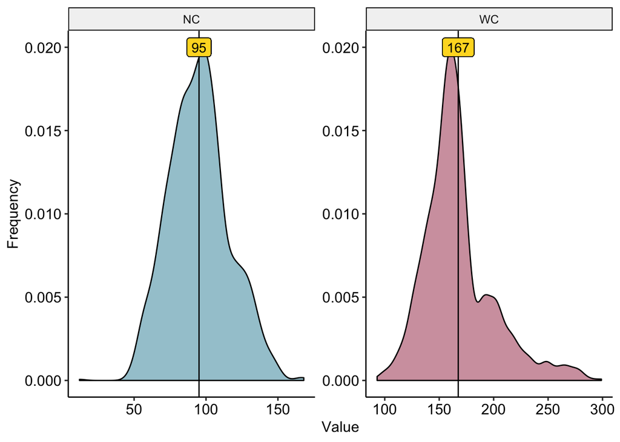

Para los 2 valores que tenemos, las distribuciones están bastante centradas alrededor de una media, por lo que reducir las distintas muestras recogidas por sujeto a la media de todas ellas es una aproximación muy razonable

## Rango de Normalidad

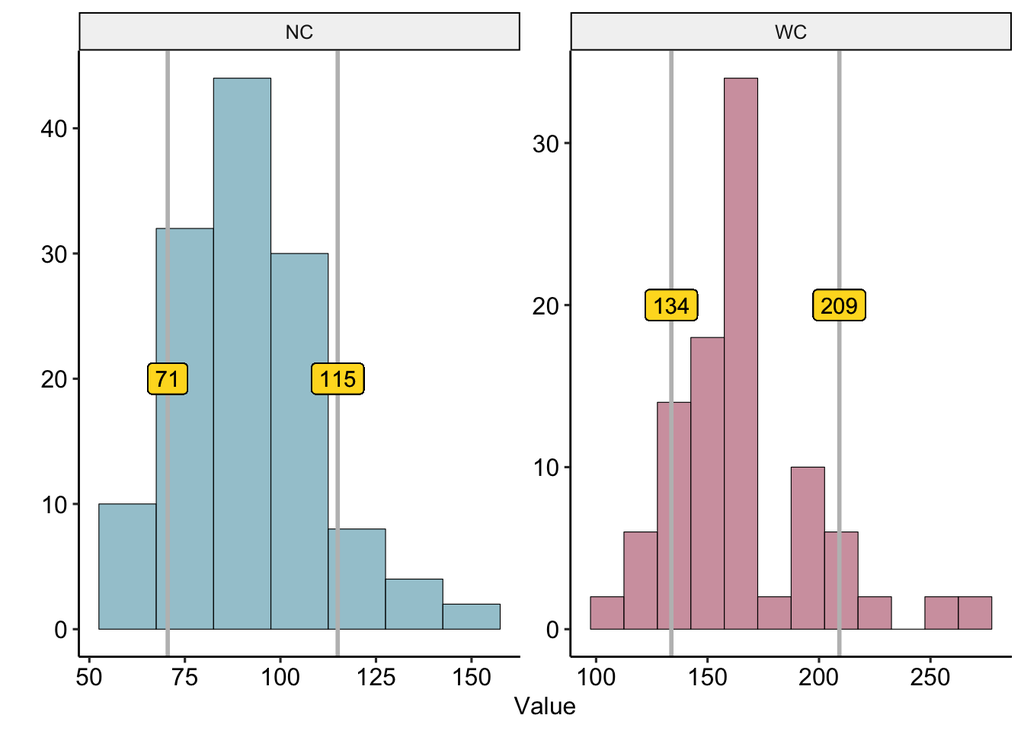

Una vez reducidos los valores a uno por animal, podemos ver la distribución que queda. Vemos que hay unos valores centrales muy marcados como ‘lo habitual’, mientras que los valores alejados de ahí son claramente inusuales. Definir la frontera entre ‘valores normales’ y ‘valores inusuales’ siempre requiere cierta arbitrariedad, pero viendo lo centradas que son las distribuciones, resolver esto por quantiles parece lo más razonable y sencillo.

(Hasta ahora estamos juntando braquicefálicos y no-braquicefálicos)

## Las razas braquicefálicas tienen atenuaciones diferentes de las demás razas?

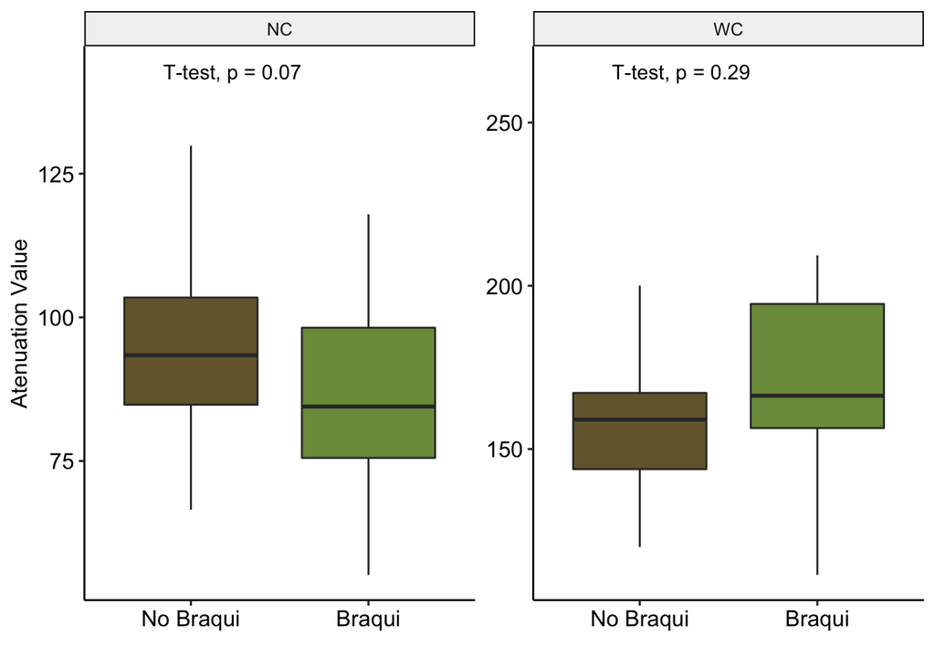

Que la cantidad de animales braquicefálicos sea superior o inferior al resto no nos sesga los datos *per se*, siempre que el procedimiento de recogida de datos sea idéntico independientemente de la raza de los perros esto no debería importarnos. Mientras tengamos “suficientes” de ambas clases para tener evidencia estadística, la proporción entre ellos no debería preocuparnos.

### Rango de normalidad diferenciando por braquicefálicos

[figure not shown]

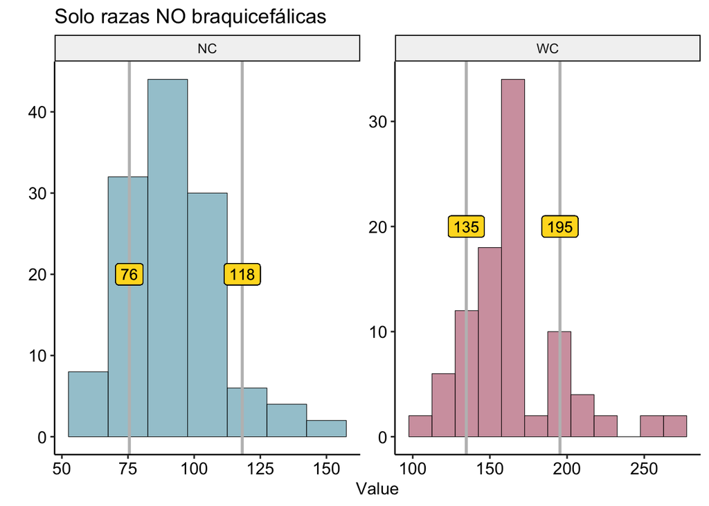

## Cuántos animales hacen falta como control

No estoy seguro de si he entendido esta pregunta. He visto algun sujeto marcado como ‘control’ que está bajo medicación (*dylan*), mientras que otros animales marcados sin patología y sin medicación no están marcados como grupo ‘control’.

## Correlacionar valores de T4 y TSH con atenuación

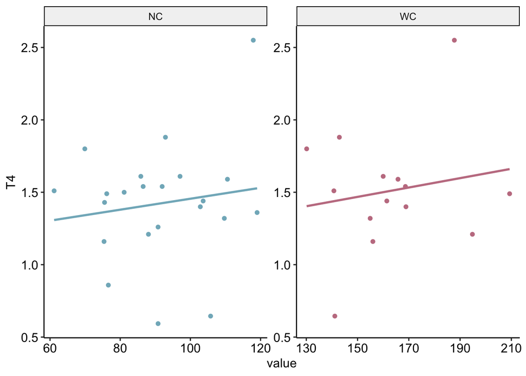

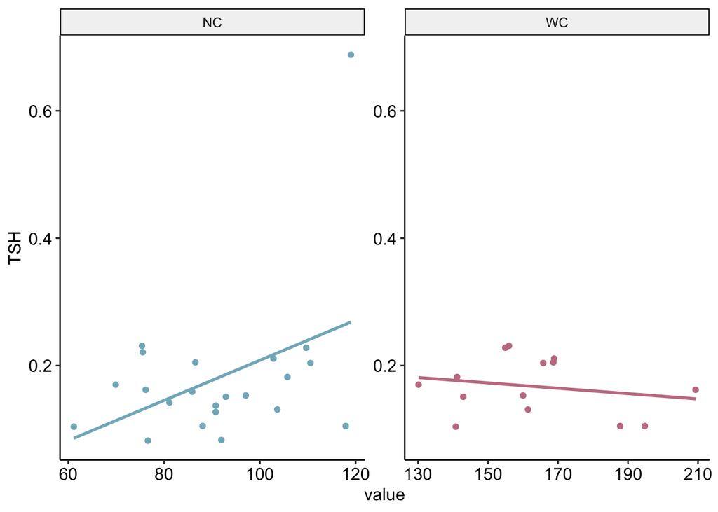

No parecer haber ninguna correlación entre los valores de tiroides y los valores en sangre.

## Correlación entre edad y atenuación de tiroides

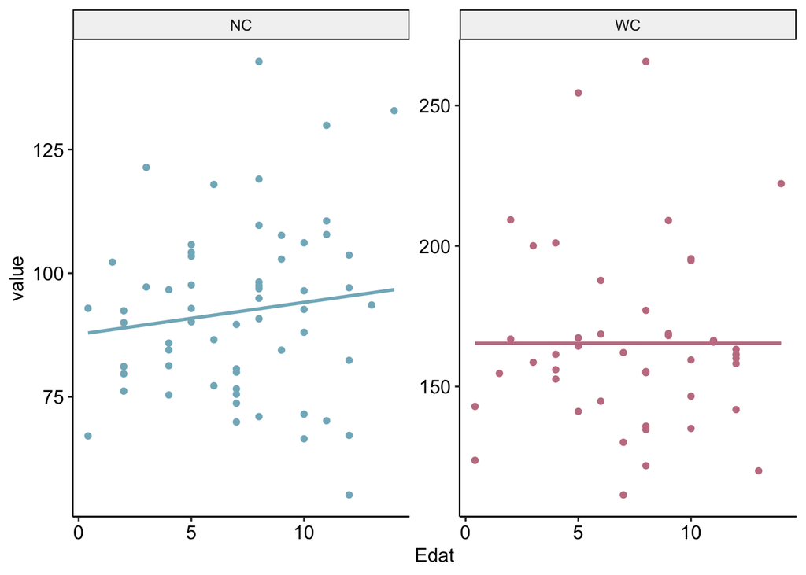

Ninguna correlación observable.

## Correlación entre peso y atenuación de tiroides

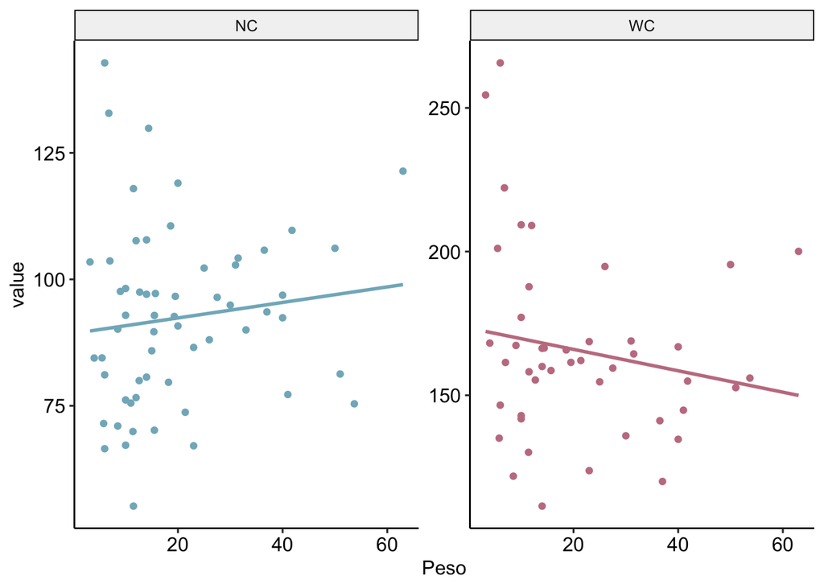

Ninguna correlación, salvo son mucho más dispersos para pesos bajos.

## Los valores de atenuación cambian según el sexo del animal?

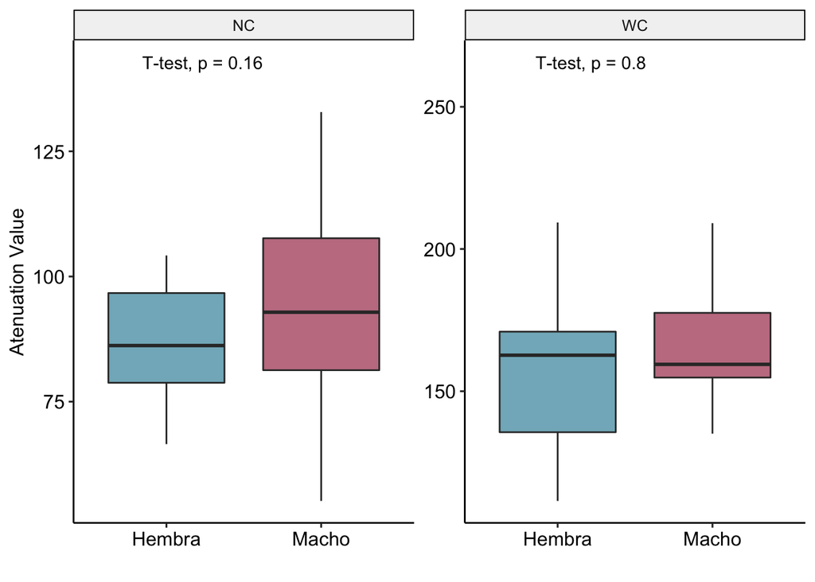

No hay evidencias significativas para encontrar diferencia entre sexos.

## Los valores de atenuación cambian según si el paciente tiene cáncer?

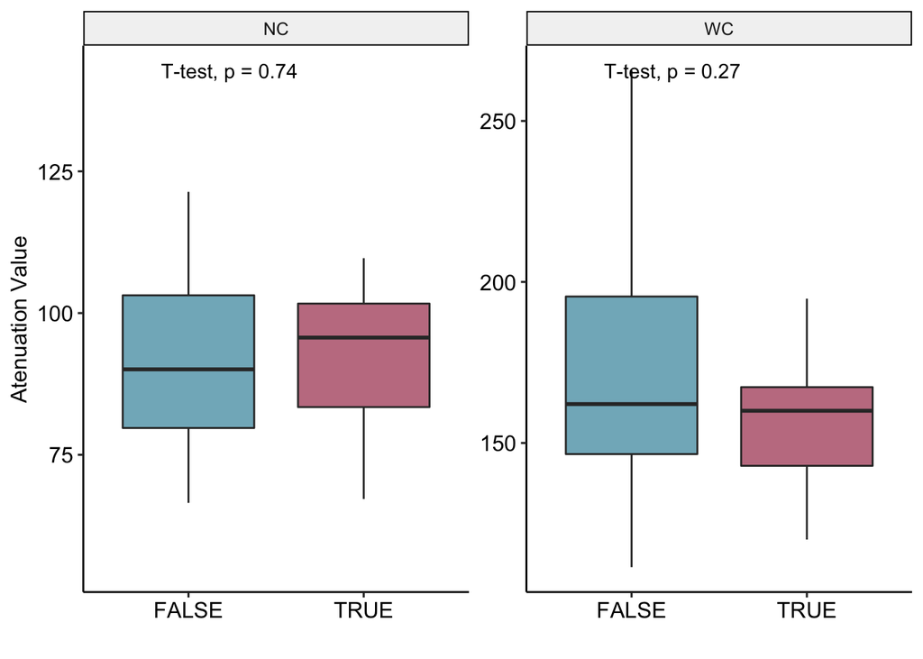

No hay diferencias significativas en el valor de atenuación de tiroides entre el grupo con cáncer y el grupo sin cáncer.

## Los valores de atenuación cambian según si el paciente está bajo medicación?

La forma más genérica de evaluar esta pregunta sería hacer un grupo con los animales en `no med` y otro grupo con todos los demás, que sería un grupo de animales que se están tomando cualquier medicación, la que sea.

```
##
##  Welch Two Sample t-test
##
## data:  y and x
## t = 0.89269, df = 71.712, p-value = 0.375
## alternative hypothesis: true difference in means is not equal to 0
## 95 percent confidence interval:
##  -10.17095  26.66553
## sample estimates:
## mean of x mean of y
##  129.0508  120.8035
```